# Fitting multiple Regression line

# Residual standard error.

The standard error shows how much the estimated values of estimated differ or deviate from the true estimates.So the resudual is the difference between the actual or obeserved values and fitted values (y-hat) .therefore

The residual standard error is 2.639 MPG, with 28 degrees of freedom.

This indicates that the observed MPG values typically differ from the model’s predicted values by approximately 2.639 MPG, measured on the response-variable scale.

A smaller residual standard error generally indicates better accurate prediction.

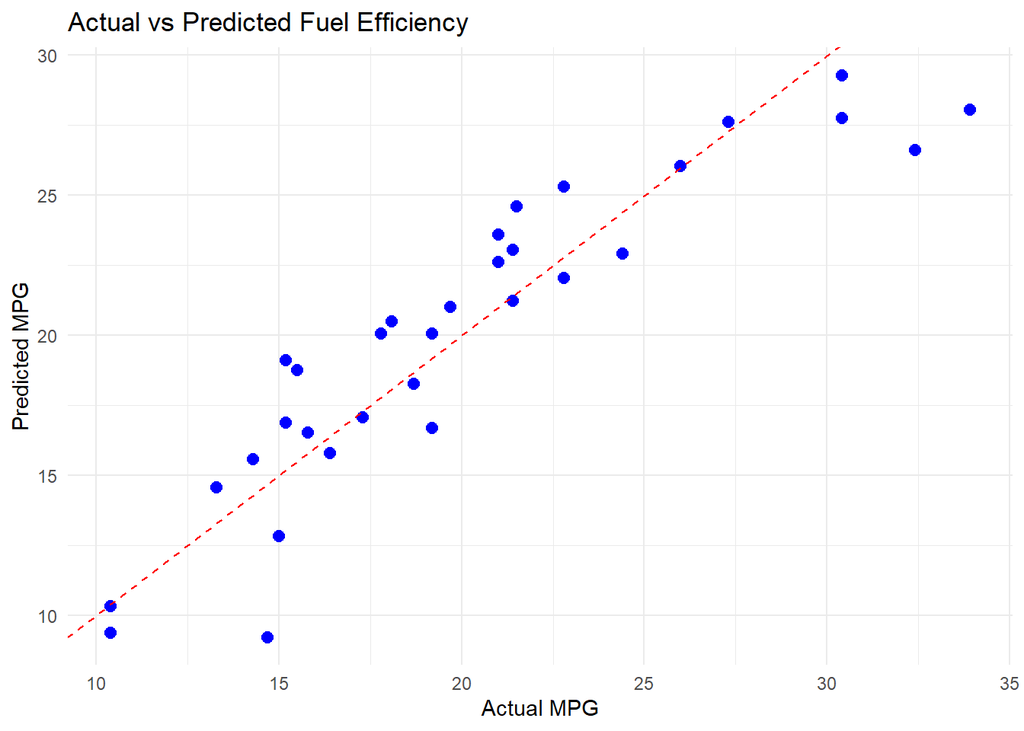

```r
library(ggplot2)

# Generate predicted MPG values
predicted_mpg <- predict(mult_linear_Line, newdata = mtcars)

# Create a dataset containing actual and predicted values
results <- data.frame(
  Actual = mtcars$mpg,
  Predicted = predicted_mpg
)

# Plot actual versus predicted values
line_graph <- ggplot(results, aes(x = Actual, y = Predicted)) +
  geom_point(colour = "blue", size = 2.5) +
  geom_abline(intercept = 0, slope = 1,
              colour = "red", linetype = "dashed") +
  labs(
    title = "Actual vs Predicted Fuel Efficiency",
    x = "Actual MPG",
    y = "Predicted MPG"
  ) +
  theme_minimal()

line_graph
```

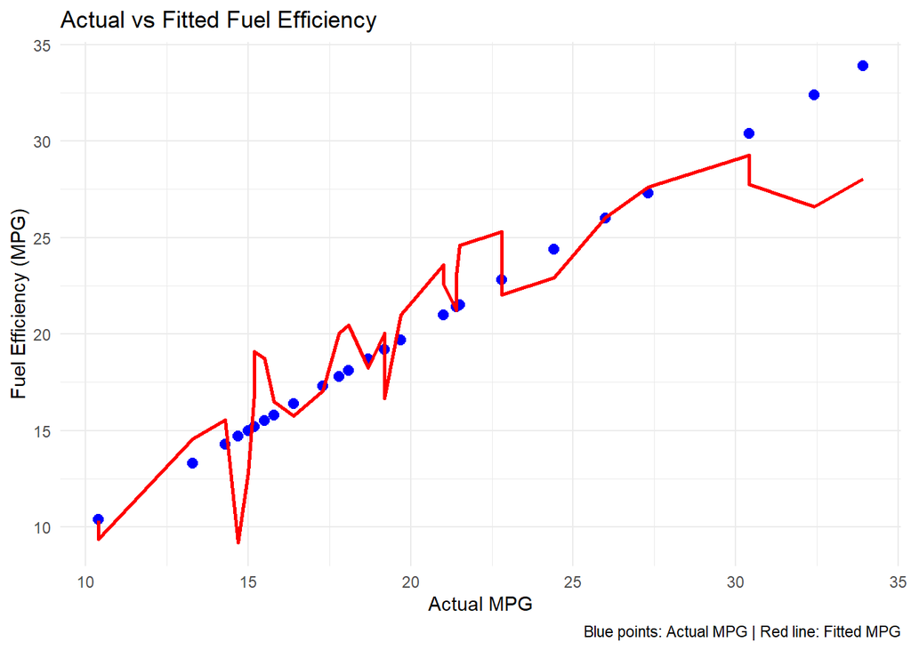

```r
library(ggplot2)

# Calculate fitted values
mtcars$Fitted_MPG <- predict(mult_linear_Line, newdata = mtcars)

# Sort observations by actual MPG for a smooth fitted line
mtcars_sorted <- mtcars[order(mtcars$mpg), ]

# Plot actual values and fitted values
ggplot(mtcars_sorted, aes(x = mpg)) +

  # Actual observed values
  geom_point(aes(y = mpg),
             colour = "blue", size = 2.5) +

  # Fitted regression values
  geom_line(aes(y = Fitted_MPG),

            colour = "red", linewidth = 1) +

  labs(
    title = "Actual vs Fitted Fuel Efficiency",
    x = "Actual MPG",
    y = "Fuel Efficiency (MPG)",
    caption = "Blue points: Actual MPG | Red line: Fitted MPG"
  ) +

  theme_minimal()
```

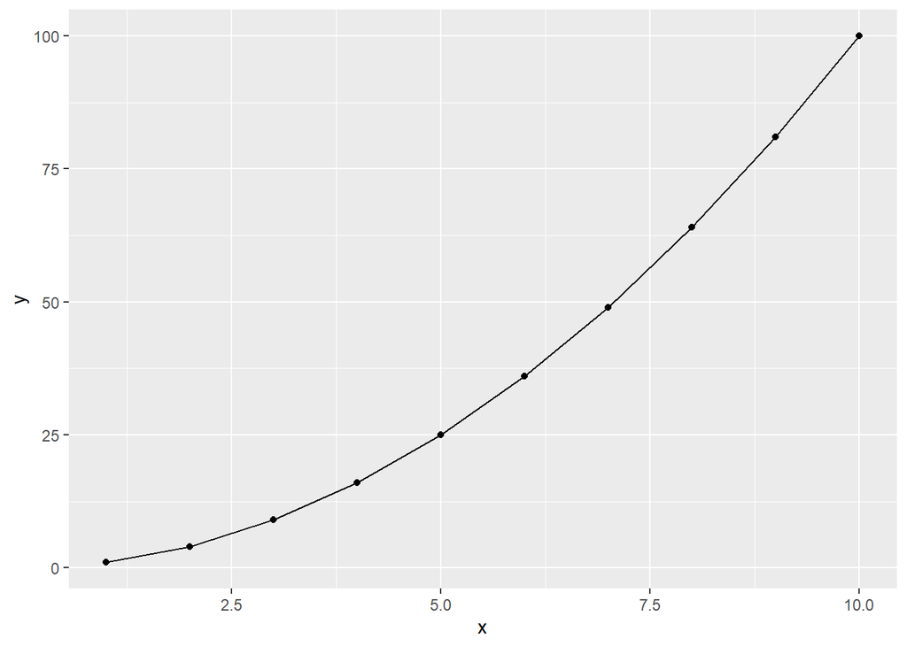

```r
library(ggplot2)
d <- data.frame(x = 1:10)
d$y <- d$x^2
ggplot(d, aes(x, y)) + geom_line() + geom_point()
```

```r
d
```

```
##     x   y
## 1   1   1
## 2   2   4
## 3   3   9
## 4   4  16
## 5   5  25
## 6   6  36
## 7   7  49
## 8   8  64
## 9   9  81
## 10 10 100
```

# Ploting unsorted bar graph

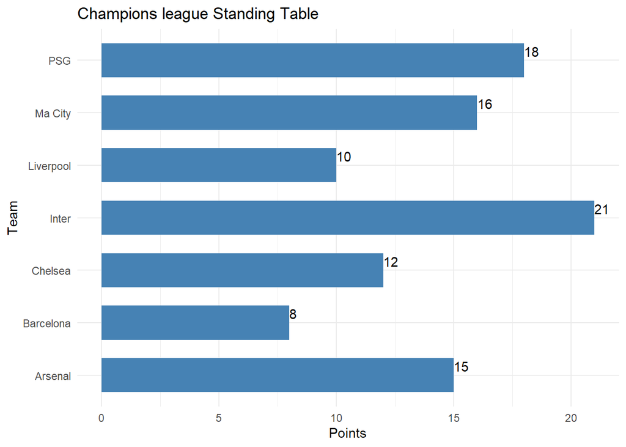

```r
library(ggplot2)
data_col<-data.frame(
  team = c("Arsenal","Chelsea","Liverpool","Barcelona","Ma City","PSG","Inter"),
  points = c(15,12,10,8,16,18,21)
  )
data_table <- data_col[order(desc(data_col$points)),]
bar_graph <- ggplot(data_table,aes(points,team,width=0.65))+

             geom_col(fill="steelblue")+
  geom_text(aes(label= points),vjust = -0.4,hjust= -0.01)+
       labs(title = "Champions league Standing Table",
       x = "Points",
       y= "Team")+
theme_minimal()
bar_graph
```

```r
library(dplyr)
data_table1 <-data_col%>%
  arrange(desc(points))
data_table
```

```
##        team points
## 7     Inter     21
## 6       PSG     18
## 5   Ma City     16
## 1   Arsenal     15
## 2   Chelsea     12
## 3 Liverpool     10
## 4 Barcelona      8
```

[output not shown]